# Diana Wall

Scientists

Türkçe

Toprak Ekolojisinin öncülerinden olan Prof. Dr. Diana Wall’un aramızdan ayrılışının anısına.

Author

Bedirhan Avdancı

Published

June 30, 2024

## Prof. Dr. Diana Wall: Toprak Ekolojisinin Öncüsü

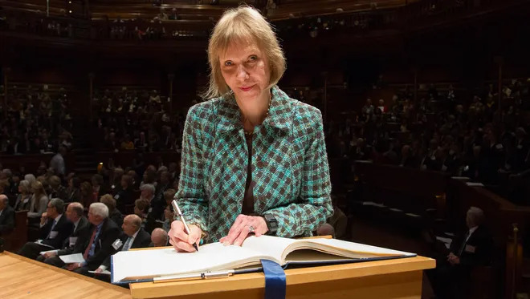

[Diana Wall](https://www.coloradoan.com/story/csu/discover/2014/10/31/diana-wall-addresses-american-academy-of-arts-and-sciences/18251725/)

Bu metin, toprak biyoçeşitliliği alanının kurucusu olan ve bilimsel çalışmalarıyla toprak ekolojisi alanında kalıcı bir iz bırakan Prof. Dr. Diana Wall’un 25 Mart 2024 tarihinde aramızdan ayrılışına atfen derlenmiştir.

Prof. Dr. Diana Wall, 27 Aralık 1943 yılında Durham, North Carolina’da dünyaya gelmiş ve çocukluğunu Lexington, Kentucky’de geçirmiştir. Akabinde, 1965 yılında Kentucky Üniversitesinde (Lexington) biyoloji alanında lisans derecesini ve 1971 yılında yine aynı üniversitede nematodlar ve bitki patolojisi alanında yaptığı çalışma ile doktora derecesini elde etmiştir. Toprak nematodlarına karşı özel ilgisi, Wall’un akademik hayatının yaklaşık 20 yılını geçireceği Kaliforniya Üniversitesi (Riverside) ile yollarının kesişmesine vesile olmuştur. Kaliforniya’da geçirdiği bu yılların ardından, çalışmalarını Kolorado Devlet Üniversitesi (CSU) bünyesinde, araştırmalardan sorumlu dekan yardımcısı ve Natural Resource Ecology Laboratuvarının yöneticisi olarak sürdürmüştür. 2008 yılına gelindiğinde ise vefat edene dek yürütücülüğünü yapacağı kurum olan CSU School of Global Environmental Sustainability bölümünü kurmuştur.

Wall, toprak nematodları ile yaptığı çalışmalar neticesinde iklim değişikliğinin toprak ekosistemi üzerindeki etkilerinin büyük ölçüde anlaşılmasını sağlamakla birlikte, toprak sağlığı hakkında küresel bir kampanya oluşmasına da öncülük etmiştir. Diana Wall, çalışmalarında, nematodların kurak ve sıcak şartlara uzun süre karşı koymalarını sağlayan fizyolojik bir mekanizma olan anhidrobiyozun (İng. anhydrobiosis) tanımlanmasına olanak sağlamıştır. Bununla birlikte, toprak besin ve etkileşim ağının ekolojik dinamiğini, çevresel değişiklikler karşısında kırılganlığını ve biyojeokimyasal süreçlere katkısını anlamak için çok sayıda çalışma yürütmüştür.

Wall, Antarktika’ya ilk seyahatini, 1989 yılında ekip arkadaşlarıyla, o dönemde hâkim bir düşünce olan soğuk, rüzgârlı ve kurak bir iklim tipine sahip kıtalardaki toprakların ne kadar çoraksa o kadar az verimli olacağı fikrini test etmek amacıyla, National Science Foundation tarafından sağlanan bir araştırma fonu yardımıyla gerçekleştirmiştir. Antarktika’daki ilk çalışmaları neticesinde mayalar, bakteriler, funguslar, rotiferler, eklembacaklılar ve besin ağının en üst düzeyinde bulunan predatör nematodları içeren bir besin ağı keşfetmişlerdir. Elde ettikleri bu bulgular, Antarktika kıtasında yapacakları “Buza Doğru” (İng. to the ice) olarak adlandırılacak ve onlarca yıl sürecek olan daha ileri düzey çalışmaların yolunu açmıştır. Diana Wall ve arkadaşlarının yapmış olduğu uzun süreli araştırmalar, toprakta yaşayan omurgasız canlıların ve mikroorganizmaların karbon döngüsü ve iklim değişikliğindeki rollerinin ve çevresel değişikliklere karşı kırılganlıklarının anlaşılmasına olanak tanımıştır. Bu çalışmaların sonuçları, iklim değişikliğinin kurak ekosistemler üzerindeki gün geçtikçe artan etkilerinin anlaşılmasına büyük oranda katkı sağlamıştır.

Wall, ileri yaşlarında bile oldukça enerjik ve heyecanlı geçirdiği akademik hayatı boyunca çok sayıda bilimsel organizasyon yönetmiş ve bu doğrultudaki birçok kuruluşu desteklemiştir. Nematologlar Derneği (SON), Amerika Biyolojik Bilimler Enstitüsü (AIBS), Amerika Ekoloji Derneği (ESA) ve Ekosistem Araştırma Merkezleri Birliği (AERC) kuruluşlarının başkanlığını yürüten Wall, ABD Ulusal Bilimler Akademisi Kutup Araştırma Kurulu (PRB), Dünya Kaynakları Enstitüsü (WRI) ve UNESCO Uluslararası Hidroloji Programı ABD Ulusal Komitesinin yanı sıra Afrika, Avrupa ve Avustralya’da birçok bilimsel komünite bünyesinde bilimsel danışman veya yönetim kurulu üyesi olarak yer almıştır.

Prof. Dr. Wall, 2001 yılında bir DIVERSITAS girişimi olan Uluslararası Biyoçeşitlilik Gözlem Yılındaki başkanlığının akabinde, toprak ekolojisi ve biyoçeşitliliğine odaklanan uluslararası bir kuruluşun eksikliğini hissetmiştir. Ardından, 2011 yılında kurulan Küresel Toprak Biyoçeşitliliği Girişiminin (The Global Soil Biodiversity Initiative; GSBI) kurucu ortaklarından biri olmuş ve ilk bilim başkanı olarak görev yapmıştır. Diana Wall’un ortak liderliğinde ve 26 farklı ülkeden 150’den fazla bilim insanının katkılarıyla biyota, ekosistem süreçleri, biyojeokimyasal süreçler ve ekolojik etkileşimleri de içeren, topraktaki yaşamın ilk kez bilimsel olarak değerlendirilmesi niteliği taşıyan Küresel Toprak Biyoçeşitliliği Atlası (The Global Soil Biodiversity Atlas), 2016 yılında GSBI bünyesinde yayınlanmıştır.

Diana, akademik hayatı boyunca birçok önemli ödül ile onurlandırılmıştır. Bunlardan bazıları, 2013 yılında kazandığı aynı zamanda Ekoloji alanının Nobel Ödülü olarak bilinen Tyler Çevresel Başarı Ödülü, 2015 yılında kazandığı University College Dublin Ulysses Madalyası, 2018’de elde ettiği Ulusal Bilimler Akademisi üyeliği ve 2019 yılında elde ettiği British Ecological Society Başkanlık Madalyası olarak sıralanabilir. Tüm bu ödüllerin yanı sıra Antarktika’daki bir vadinin ismi Diana Wall’un yapmış olduğu bilimsel çalışmalara ithafen Wall Valley olarak isimlendirilmiştir.

Diana Wall’un da üyesi olduğu Küresel Sürdürülebilir Tarım ve Çevre Girişimi (The Global Initiative of Sustainable Agriculture and Environment; GSIAE) ve bu girişimin bilimsel dergisi niteliğinde olan Sustainable Agriculture and Environment (JSAE), Diana Wall’un toprak ekolojisine ve küresel politikalara yaptığı olağanüstü katkıları onore etmek amacıyla, Aralık 2024’te JSAE bünyesinde Diana Wall’a ithafen özel bir sayı yayınlayacağını ve bu özel sayının her yıl düzenli olarak yayınlanmaya devam edeceğini duyurdu. Tüm bunların yanı sıra, kariyerinin erken ve orta safhasında olan toprak bilimciler için her yıl düzenli olarak verilecek olan “Diana Wall” isimli bir ödül oluşturulacağı da GSIAE tarafından duyuruldu ve değerlendirme aşamasında, gelişmekte olan ülkelerden katılımcılara ve kadın bilim insanlarına öncelik verileceği de belirtildi.

### Kişisel notlarım

Henüz kariyerinin başında bir toprak ekoloğu adayı olarak, Sayın Prof. Dr. Diana Wall’un ulaşmış olduğu bilimsel seviyeyi ancak bir hedef olarak belirleyebileceğimi söylemek isterim. Diana Wall, hayli heyecanla okuduğum makaleleriyle, bilimsel çalışmalar gerçekleştirmek için can attığım bu alanda bana yol gösterici olmuş ve motivasyon sağlamıştır. Şüphesiz, Wall, bilimsel hayatım boyunca örnek alacağım yegâne bilim insanlarından biri olacaktır. Bu olağanüstü katkıları için Profesör Doktor Diana Wall’a teşekkürü borç bilirim.

Tüm bunların yanı sıra, Sayın Wall ile tanışamamış olmak içimde bir ukde olarak kalacaktır…

### Takip etmek isteyenler için

**[Prof. Dr. Diana Wall’un Google Scholar Profili](https://scholar.google.com/citations?hl=tr&user=pimG8rwAAAAJ&view_op=list_works)**

**Wall’un en çok atıf alan makalesi “Global biodiversity scenarios for the year 2100”**

**[Wall’un Ekim 2022’de katılmış olduğu bir podcast programı “Nematodes with Diana Wall”](https://open.spotify.com/episode/42DSCQT5QADBCVOtKIBpqs?si=nz4QSluhTF6uSw77xY5lMg)**

**[Wall’un Kasım 2023’te katılmış olduğu bir podcast programı “Antarctic Soils”](https://open.spotify.com/episode/22YvZtylYcj9viRyyGYL8H?si=fvkXS4hZQ8qyZ-oy_3yzvA)**

**[The Global Soil Biodiversity Initiative; GSBI](https://www.globalsoilbiodiversity.org/)**

### Kaynakça

• Görsel linki: https://www.coloradoan.com/story/csu/discover/2014/10/31/diana-wall-addresses-american-academy-of-arts-and-sciences/18251725/

• Bardgett, R. D. (2024). Diana Wall obituary: ecologist who foresaw the importance of soil biodiversity. Nature, 629(8013), 754-754.

• Singh, B. K., Trivedi, P., Egidi, E., & Delgado‐Baquerizo, M. (2024). Prof Diana Wall: A pioneering researcher and advocate of global soil biodiversity. Journal of Sustainable Agriculture and Environment, 3(2), e12107.

• Lubchenco, J., & Galvin, K. A. (2024). Diana H. Wall (1943–2024). Science, 384(6698), 852-852.

• [Nik Olsen. (2024). Diana Wall, groundbreaking soil ecologist who left a lifetime legacy at Colorado State University.](https://source.colostate.edu/diana-wall/)